# Chapter 10

Bryan Li

2/27/2019

#### 3)

1. The association between weight and fuel efficiency seems to be relatively strong and linear. It is in the negative direction. There is some potential for a non-linear (curved) relationship, however.
2. The slope of the line predicts that for every 1000-pound increase in weight, the fuel efficiency decreases by approximately 7.65.
3. A linear model may not be appropriate for this data as the residuals seem to be somewhat curved/quadratic, in a U-shape.

#### 5)

1. This model appears to be better, with both a higher R-squared along with more random residuals.
2. `[gal/100 mi] = 0.625 + 1.178 [weight]`
3. The slope of the line predicts that for every 1000-pound increase in weight, approximately 1.178 more gallons of fuel will be needed to drive 100 miles.
4. 21.06 miles/gallon.

#### 24)

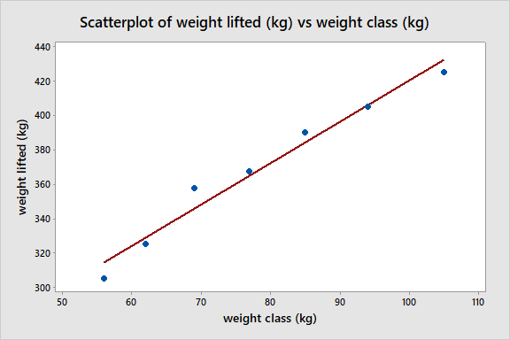

1. `[weight lifted] = 2.401 * [weight class] + 179.9`

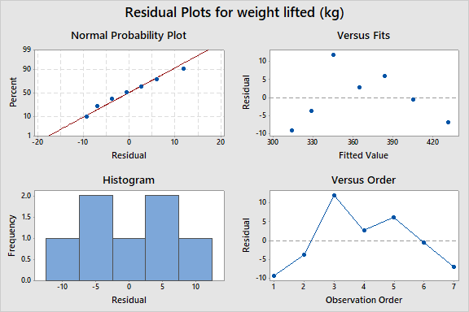

2. The residuals appear to have an obvious curve; thus the linear model is not appropriate.
3. `[weight lifted]^2 = -461800 + 137992 * log([weight class])`
4. The residuals had less of an obvious shape, making my model better compared to the linear model.

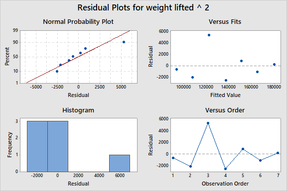

5. Boevski had the most surprising performance as he deviated most strongly from the line of fit (seen in his residual).

#### 32)

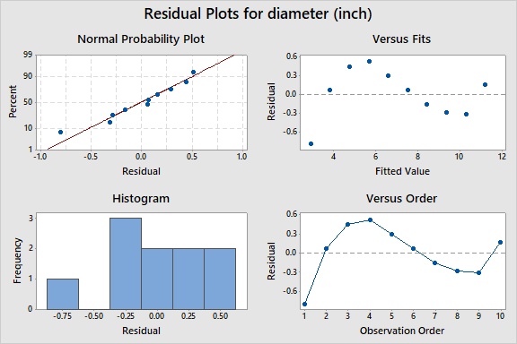

1. There is a very clear curve to the model that almost appears cubic. Thus I do not feel that a linear model is correct.
2. The fit would be about the same (or rather simply does not matter) as either way a linear fit would not apply such a dataset (that looks almost cubic).